# `ggrain::geom_rain()`

BSTA 526 Functions of the Week

Create rain plots with ggplot

Author

Daniel Klee

Published

February 5, 2026

# 1 `ggrain::geom_rain()`

`geom_rain()` is from the `ggrain` package. This function allows for the creation of so-called “rain” plots with `ggplot`.

Additional information can be found on the [CRAN website](https://cran.r-project.org/web/packages/ggrain/vignettes/ggrain.html), or by typing `?geom_rain` in the console.

# 2 What is it for?

In conjunction with `ggplot`, `geom_rain()` will take numeric (y-axis) and categorical (x-axis) data to generate a rain plot, which is a compound plot with density (i.e., half-violin), dot plot, and boxplot representations of the data. These plots get their name from the fact that they look a little like raindrops coming out of a cloud. (*Amusingly, the boxplot element is sometimes referred to as the “train in the rain.”*)

# 3 Examples

For the following examples, we’ll primarily be using the [palmerpenguins](https://allisonhorst.github.io/palmerpenguins/) package. The data in `penguins` represent various measurements of different penguin species recorded near Palmer Station in Antarctica.

```r
library(palmerpenguins)
data("penguins")
```

(*Note*: In an effort to minimize code and simplify the examples, plot titles are omitted and variable names are left mostly unchanged.)

## 3.1 Simple Rain Plots

Through simple implementations of `geom_rain()`, we can get a sense of the default settings before exploring the various other argument options for plot customization. Plots can be created using a single numeric variable as an input, or by combining a numeric variable with a categorical variable.

### 3.1.1 One numeric variable

Let’s begin by simply plotting the variable `bill_length_mm`, which represents penguin bill length (mm):

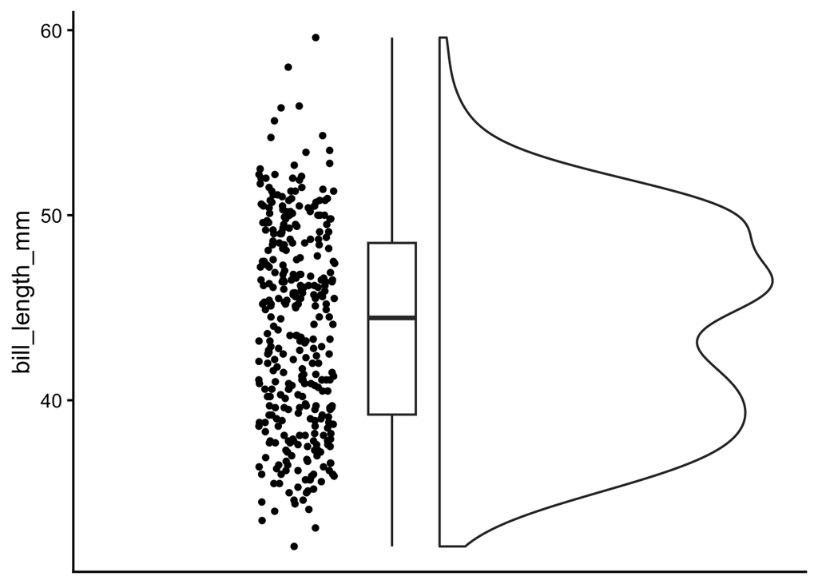

```r
# Pipe the data
penguins |>

  # Create a ggplot
  ggplot(aes(

    # Select our variable(s)
    x = 1,
    y = bill_length_mm
  )) +

  # Add the rain plot layer
  geom_rain() +

  # Add a theme
  theme_classic(base_size = 15) +

  # Remove the x-axis labels
  theme(axis.title.x = element_blank(),
        axis.ticks.x = element_blank(),
        axis.text.x = element_blank())
```

Notice that we needed to provide information about the x-axis (i.e., x = 1), which meant that we also had to use `theme()` to remove the extraneous information from x-axis.

### 3.1.2 Rotated plots

By design, `geom_rain()` only accepts the measurement variable along the y-axis. However, if we want to rotate the plot 90-degrees, we can do so using `coord_flip()`:

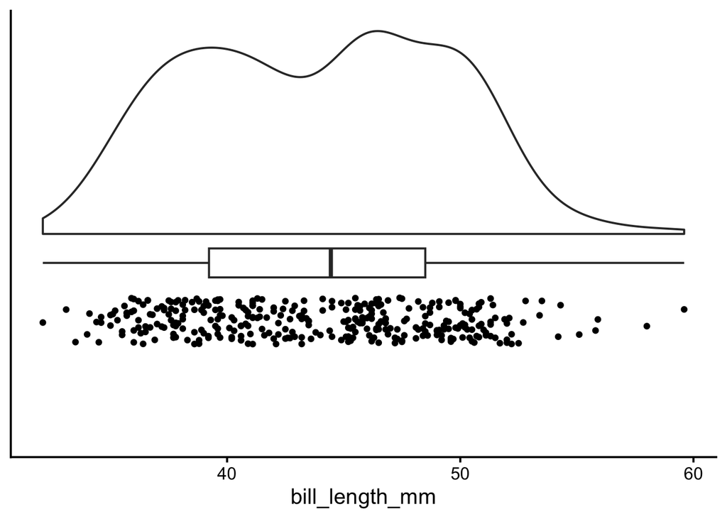

```r
penguins |>
  ggplot(aes(
    x = 1,
    y = bill_length_mm
  )) +
  geom_rain() +
  theme_classic(base_size = 15) +
  theme(axis.title.y = element_blank(),
        axis.ticks.y = element_blank(),
        axis.text.y = element_blank()) +

  # Swap the x- and y-axes
  coord_flip()
```

### 3.1.3 Combining numeric and categorical data

If we wish to separate our measurement according to a particular categorical variable, we can do so easily by adjusting `aes()` in `ggplot`, much like for any other geom layer. Continuing to use `bill_length_mm` as our numeric measurement, let’s now add the categorical variable `island` to our graphic, which represents penguin island of origin:

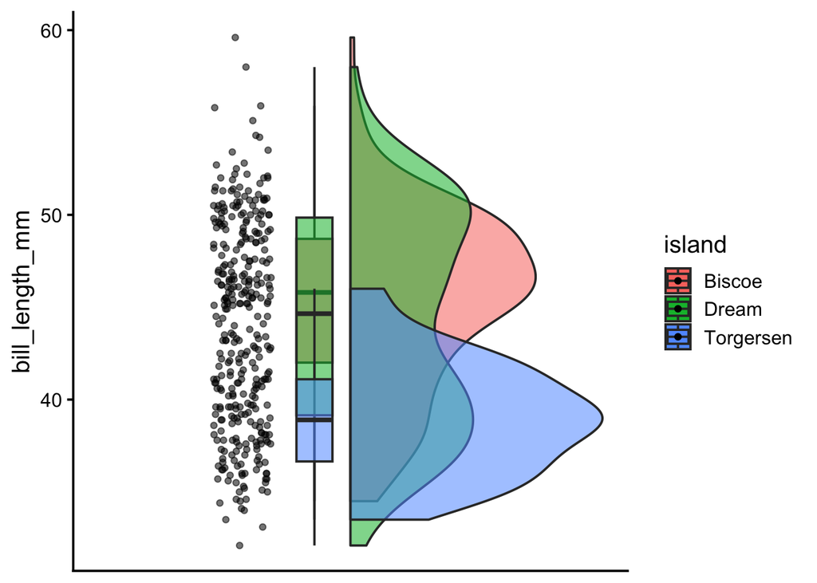

```r
penguins |>
  ggplot(aes(
    x = 1,
    y = bill_length_mm,

    # Fill in color by `island` and increase transparency
    fill = island,
    alpha = 0.5)) +

  geom_rain() +
  theme_classic(base_size = 15) +
  theme(axis.title.x = element_blank(),
        axis.ticks.x = element_blank(),
        axis.text.x = element_blank()) +

  # Remove the extra legend element for `alpha`
  guides(alpha = "none")
```

(*Notice that the dots do not automatically inherit the colors from* `fill`.)

It can be difficult to discern characteristics of the distribution when all groups are aligned in a single column. To clean things up a bit, we can assign our categorical variable to the x-axis:

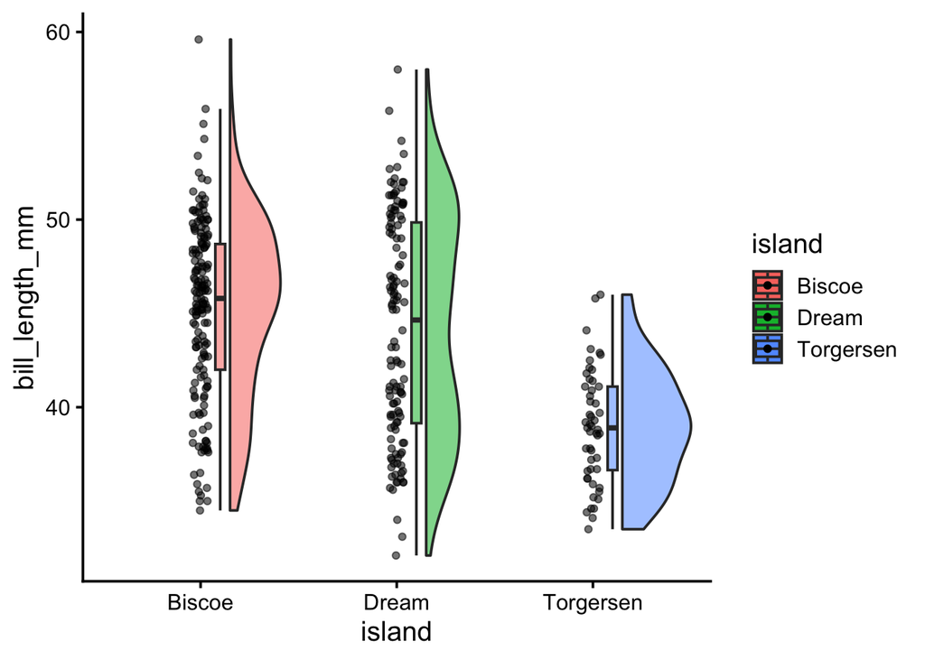

```r
penguins |>
  ggplot(aes(

    # Assign `island` to the x-axis
    x = island,

    y = bill_length_mm,
    fill = island,
    alpha = 0.5)) +
  geom_rain() +
  theme_classic(base_size = 15) +
  guides(alpha = "none")
```

## 3.2 Exploring Additional Arguments

Now that we have a basic understanding of `geom_rain()`, we can touch on a few other useful arguments for customizing our rain plots.

### 3.2.1 Adding a covariate

If we’re interested in exploring a third variable as a covariate, we can use the `cov` argument in `geom_rain()` to add color shading to the dot plot. We can specify a numeric covariate, such as `flipper_length_mm`:

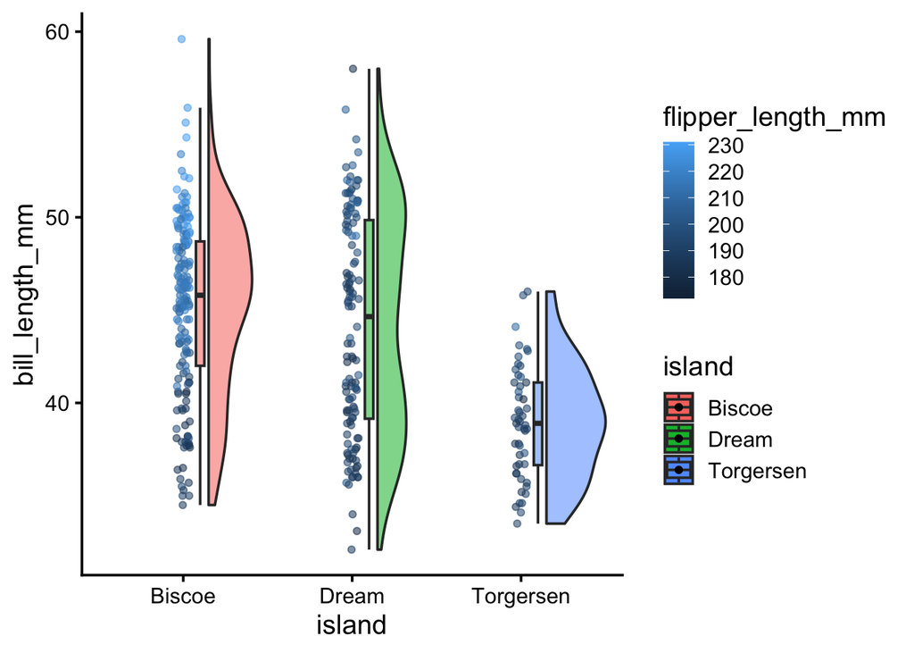

```r
penguins |>
  ggplot(aes(
    x = island,
    y = bill_length_mm,
    fill = island,
    alpha = 0.5)) +
  geom_rain(

    # Add `flipper_length_mm` as a covariate
    cov = "flipper_length_mm"

  ) +
  theme_classic(base_size = 15) +
  guides(alpha = "none")
```

We can also specify a categorical covariate, such as `species`:

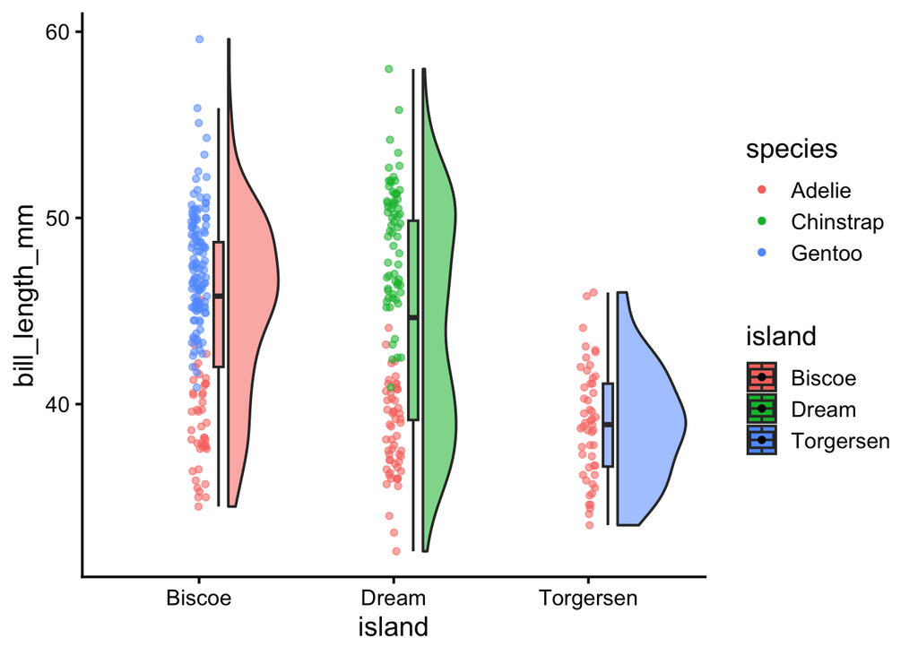

```r
penguins |>
  ggplot(aes(
    x = island,
    y = bill_length_mm,
    fill = island,
    alpha = 0.5)) +
  geom_rain(

    # Add `species` as a covariate
    cov = "species"

  ) +
  theme_classic(base_size = 15) +
  guides(alpha = "none")
```

### 3.2.2 Plot orientation

The orientation of rain plots can be mirrored along the y-axis in a number of ways using the argument `rain.side`. Accepted values tell the plot to orient “right,” “left,” or “flanking,” using shorthand like `r`, `l`, `f1x1`, etc. To demonstrate, let’s select `sex` as our categorical variable, since it only has two levels. We can adjust the two resulting rain plots to face away/toward each other:

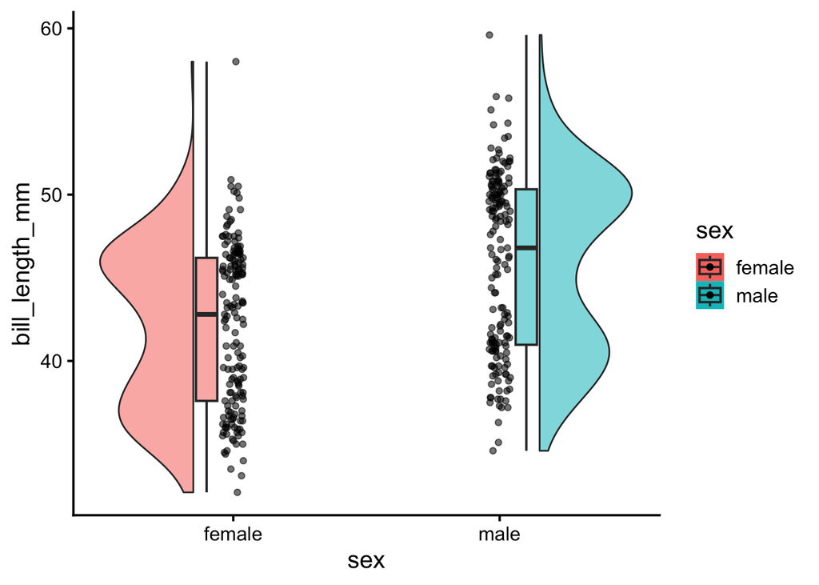

```r
penguins |>

  # Select `sex` and `bill_length_mm`
  select(sex, bill_length_mm) |>

  # Omit missing values
  na.omit() |>

  ggplot(aes(
    x = sex,
    y = bill_length_mm,
    fill = sex,
    alpha = 0.5)) +
  geom_rain(

    # Tell the plot to adopt a "flanking" orientation
    rain.side = "f1x1"

  ) +
  theme_classic(base_size = 15) +
  guides(alpha = "none")
```

### 3.2.3 Modifying isolated plot elements

On a more granular level, aspects of the density, boxplot, and dot plot elements can be adjusted using `violin.args`, `violin.args.pos`, `boxplot.args`, `boxplot.args.pos`, `point.args`, and `point.args.pos`. To illustrate a few examples, let’s plot `body_mass_g` and `species`:

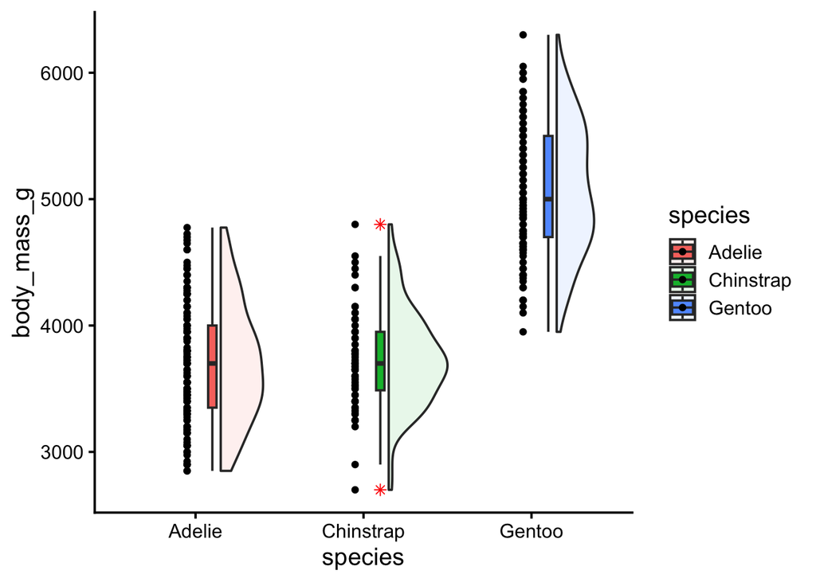

```r
penguins |>
  ggplot(aes(
    x = species,
    y = body_mass_g,
    fill = species)) +
  geom_rain(

    # Label boxplot outliers as asterisks (*) and make them red
    boxplot.args = list(
      outlier.shape = 8,
      outlier.color = "red"),

    # Change the transparency of the density plots
    violin.args = list(alpha = 0.1),

    # Remove jitter and nudge the position of the dot plots
    point.args.pos = list(
      position = position_nudge(
        x = -0.05))
    ) +
  theme_classic(base_size = 15)
```

Note that we need to use `list()` to input adjustments to these various arguments. Unfortunately, using `list()` here can reset certain defaults (e.g., removing jitter of the dots), so some settings may need to be reset!

### 3.2.4 Paired Data

As a final example, we can draw lines between categories to represent paired/longitudinal data. Unfortunately, `penguins` will not be a suitable dataset for this example, since we need long-format data with multiple observations for each individual. Instead, we can load the `sleep` dataset, which shows the effects of two soporific drugs on changes in sleep (`extra`) at two time points (`group`) for 10 patients (`ID`). The data are included as a pre-loaded dataset in R, so there is no need to download an additional package.

To show paired/longitudinal data, use the `id.long.var` argument:

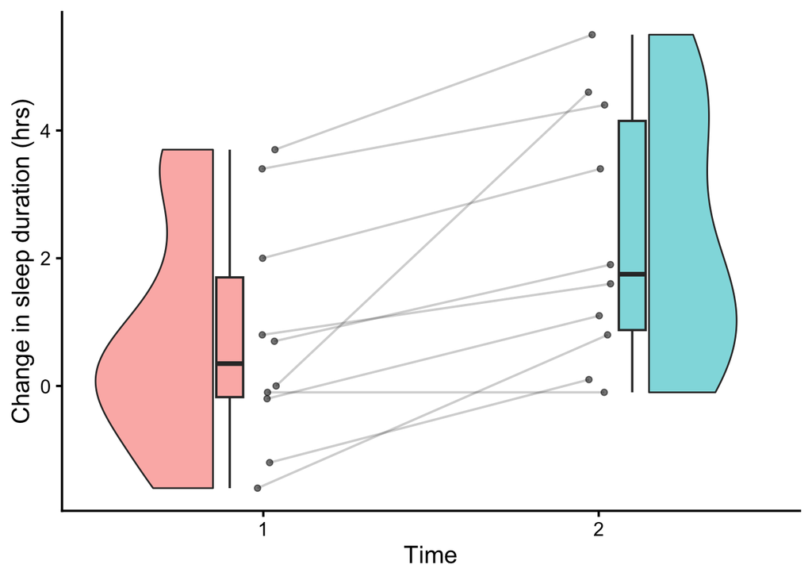

```r
# Load `sleep` dataset
data("sleep")

sleep |>
  ggplot(aes(
    x = group,
    y = extra,
    fill = group,
    alpha = 0.5)) +
  geom_rain(
    rain.side = "f1x1",

    # Specify `ID` as the pairing variable
    id.long.var = "ID"

  ) +
  theme_classic(base_size = 15) +

  # Fix confusing labels on the axes
  labs(
    x = "Time",
    y = "Change in sleep duration (hrs)"
  ) +

  # Remove the legend
  theme(legend.position = "none") +

  guides(alpha = "none")
```

As a final note, the lines in this plot can be adjusted using the `line.args` and `line.args.pos` arguments.

# 4 Is it helpful?

## 4.1 Pros

- Rain plots immediately provide information about sample size, shape, center, and spread of distributions without having to create or query multiple other metrics or plots.
- Argument options offer a fair range of customizability for different plotting scenarios.

## 4.2 Cons

- Rain plots have a tendency to look cluttered, since they present a lot of (sometimes redundant) information in a very compact space.
- Modifying specific plot elements can be somewhat clunky and unintuitive.
- There is ostensibly no method of re-ordering the dot plot, boxplot, and density graphics (e.g., having the dot plot appear in the middle, between the boxplot and density plot).

## 4.3 Verdict: Is it helpful?

In short, **it depends**… These plots can be very informative and aesthetically-pleasing representations of data if we’re working with two or maybe three groups along a common numeric variable. In particular, rain plots seem to be useful for data exploration, since they give us a lot of information very quickly. However, as mentioned above, some of this information (e.g., center; spread) is redundant between plot elements, so it’s not necessarily a *concise* illustration of the data. In fact, there can sometimes be **too much** information in these plots.

Ultimately, `geom_rain()` seems like a good tool have on-hand for data exploration, but I personally don’t plan to use it regularly for finalized reports.